# Risk Factor Analysis

## Outcome Variable

**Outcome Variable:** pers_wast

## Predictor Variables

**Intervention Variable:** feducyrs

**Adjustment Set:**

- arm
- W_mage
- meducyrs
- W_mhtcm
- W_mwtkg
- W_mbmi
- W_gagebrth
- W_birthwt
- W_birthlen
- single
- delta_W_mage
- delta_meducyrs
- delta_W_mhtcm
- delta_W_mwtkg
- delta_W_mbmi
- delta_W_gagebrth
- delta_W_birthwt
- delta_W_birthlen
- delta_single

## Stratifying Variables

The analysis was stratified on these variable(s):

- agecat
- studyid
- country

## Data Summary

| agecat | studyid | country | feducyrs | pers_wast | n_cell | n |
| --- | --- | --- | --- | --- | --- | --- |
| 0-24 months | COHORTS | GUATEMALA | High | 0 | 182 | 999 |
| 0-24 months | COHORTS | GUATEMALA | High | 1 | 6 | 999 |
| 0-24 months | COHORTS | GUATEMALA | Low | 0 | 431 | 999 |
| 0-24 months | COHORTS | GUATEMALA | Low | 1 | 14 | 999 |
| 0-24 months | COHORTS | GUATEMALA | Medium | 0 | 351 | 999 |
| 0-24 months | COHORTS | GUATEMALA | Medium | 1 | 15 | 999 |
| 0-24 months | COHORTS | INDIA | High | 0 | 454 | 1242 |
| 0-24 months | COHORTS | INDIA | High | 1 | 33 | 1242 |
| 0-24 months | COHORTS | INDIA | Low | 0 | 366 | 1242 |
| 0-24 months | COHORTS | INDIA | Low | 1 | 38 | 1242 |
| 0-24 months | COHORTS | INDIA | Medium | 0 | 324 | 1242 |
| 0-24 months | COHORTS | INDIA | Medium | 1 | 27 | 1242 |
| 0-24 months | COHORTS | PHILIPPINES | High | 0 | 892 | 2659 |
| 0-24 months | COHORTS | PHILIPPINES | High | 1 | 31 | 2659 |
| 0-24 months | COHORTS | PHILIPPINES | Low | 0 | 736 | 2659 |
| 0-24 months | COHORTS | PHILIPPINES | Low | 1 | 44 | 2659 |
| 0-24 months | COHORTS | PHILIPPINES | Medium | 0 | 897 | 2659 |
| 0-24 months | COHORTS | PHILIPPINES | Medium | 1 | 59 | 2659 |
| 0-24 months | GMS-Nepal | NEPAL | High | 0 | 126 | 596 |
| 0-24 months | GMS-Nepal | NEPAL | High | 1 | 20 | 596 |
| 0-24 months | GMS-Nepal | NEPAL | Low | 0 | 221 | 596 |
| 0-24 months | GMS-Nepal | NEPAL | Low | 1 | 36 | 596 |
| 0-24 months | GMS-Nepal | NEPAL | Medium | 0 | 169 | 596 |
| 0-24 months | GMS-Nepal | NEPAL | Medium | 1 | 24 | 596 |
| 0-24 months | JiVitA-3 | BANGLADESH | High | 0 | 3853 | 15189 |
| 0-24 months | JiVitA-3 | BANGLADESH | High | 1 | 178 | 15189 |
| 0-24 months | JiVitA-3 | BANGLADESH | Low | 0 | 5568 | 15189 |
| 0-24 months | JiVitA-3 | BANGLADESH | Low | 1 | 367 | 15189 |
| 0-24 months | JiVitA-3 | BANGLADESH | Medium | 0 | 4914 | 15189 |
| 0-24 months | JiVitA-3 | BANGLADESH | Medium | 1 | 309 | 15189 |

[output cut: 294 more lines]

The following strata were considered:

- agecat: 0-24 months, studyid: COHORTS, country: GUATEMALA
- agecat: 0-24 months, studyid: COHORTS, country: INDIA
- agecat: 0-24 months, studyid: COHORTS, country: PHILIPPINES
- agecat: 0-24 months, studyid: GMS-Nepal, country: NEPAL
- agecat: 0-24 months, studyid: JiVitA-3, country: BANGLADESH
- agecat: 0-24 months, studyid: JiVitA-4, country: BANGLADESH
- agecat: 0-24 months, studyid: LCNI-5, country: MALAWI
- agecat: 0-24 months, studyid: MAL-ED, country: BANGLADESH
- agecat: 0-24 months, studyid: MAL-ED, country: INDIA
- agecat: 0-24 months, studyid: MAL-ED, country: NEPAL
- agecat: 0-24 months, studyid: MAL-ED, country: PERU
- agecat: 0-24 months, studyid: MAL-ED, country: SOUTH AFRICA
- agecat: 0-24 months, studyid: MAL-ED, country: TANZANIA, UNITED REPUBLIC OF
- agecat: 0-24 months, studyid: NIH-Crypto, country: BANGLADESH
- agecat: 0-24 months, studyid: PROBIT, country: BELARUS
- agecat: 0-24 months, studyid: PROVIDE, country: BANGLADESH
- agecat: 0-24 months, studyid: SAS-CompFeed, country: INDIA
- agecat: 0-24 months, studyid: SAS-FoodSuppl, country: INDIA
- agecat: 0-24 months, studyid: TanzaniaChild2, country: TANZANIA, UNITED REPUBLIC OF
- agecat: 0-24 months, studyid: ZVITAMBO, country: ZIMBABWE
- agecat: 0-6 months, studyid: COHORTS, country: PHILIPPINES
- agecat: 0-6 months, studyid: GMS-Nepal, country: NEPAL
- agecat: 0-6 months, studyid: JiVitA-3, country: BANGLADESH
- agecat: 0-6 months, studyid: MAL-ED, country: BANGLADESH
- agecat: 0-6 months, studyid: MAL-ED, country: INDIA
- agecat: 0-6 months, studyid: MAL-ED, country: NEPAL
- agecat: 0-6 months, studyid: MAL-ED, country: PERU
- agecat: 0-6 months, studyid: MAL-ED, country: SOUTH AFRICA
- agecat: 0-6 months, studyid: MAL-ED, country: TANZANIA, UNITED REPUBLIC OF
- agecat: 0-6 months, studyid: NIH-Crypto, country: BANGLADESH
- agecat: 0-6 months, studyid: PROBIT, country: BELARUS
- agecat: 0-6 months, studyid: PROVIDE, country: BANGLADESH
- agecat: 0-6 months, studyid: TanzaniaChild2, country: TANZANIA, UNITED REPUBLIC OF
- agecat: 0-6 months, studyid: ZVITAMBO, country: ZIMBABWE
- agecat: 6-24 months, studyid: COHORTS, country: GUATEMALA
- agecat: 6-24 months, studyid: COHORTS, country: INDIA
- agecat: 6-24 months, studyid: COHORTS, country: PHILIPPINES
- agecat: 6-24 months, studyid: GMS-Nepal, country: NEPAL
- agecat: 6-24 months, studyid: JiVitA-3, country: BANGLADESH
- agecat: 6-24 months, studyid: JiVitA-4, country: BANGLADESH
- agecat: 6-24 months, studyid: LCNI-5, country: MALAWI
- agecat: 6-24 months, studyid: MAL-ED, country: BANGLADESH
- agecat: 6-24 months, studyid: MAL-ED, country: INDIA
- agecat: 6-24 months, studyid: MAL-ED, country: NEPAL
- agecat: 6-24 months, studyid: MAL-ED, country: PERU
- agecat: 6-24 months, studyid: MAL-ED, country: SOUTH AFRICA
- agecat: 6-24 months, studyid: MAL-ED, country: TANZANIA, UNITED REPUBLIC OF
- agecat: 6-24 months, studyid: NIH-Crypto, country: BANGLADESH
- agecat: 6-24 months, studyid: PROBIT, country: BELARUS
- agecat: 6-24 months, studyid: PROVIDE, country: BANGLADESH
- agecat: 6-24 months, studyid: SAS-CompFeed, country: INDIA
- agecat: 6-24 months, studyid: SAS-FoodSuppl, country: INDIA
- agecat: 6-24 months, studyid: TanzaniaChild2, country: TANZANIA, UNITED REPUBLIC OF
- agecat: 6-24 months, studyid: ZVITAMBO, country: ZIMBABWE

### Dropped Strata

Some strata were dropped due to rare outcomes:

- agecat: 0-24 months, studyid: LCNI-5, country: MALAWI
- agecat: 0-24 months, studyid: MAL-ED, country: BANGLADESH
- agecat: 0-24 months, studyid: MAL-ED, country: INDIA
- agecat: 0-24 months, studyid: MAL-ED, country: NEPAL
- agecat: 0-24 months, studyid: MAL-ED, country: PERU
- agecat: 0-24 months, studyid: MAL-ED, country: SOUTH AFRICA
- agecat: 0-24 months, studyid: MAL-ED, country: TANZANIA, UNITED REPUBLIC OF
- agecat: 0-24 months, studyid: NIH-Crypto, country: BANGLADESH
- agecat: 0-24 months, studyid: PROVIDE, country: BANGLADESH
- agecat: 0-6 months, studyid: JiVitA-3, country: BANGLADESH
- agecat: 0-6 months, studyid: MAL-ED, country: BANGLADESH
- agecat: 0-6 months, studyid: MAL-ED, country: INDIA
- agecat: 0-6 months, studyid: MAL-ED, country: NEPAL
- agecat: 0-6 months, studyid: MAL-ED, country: PERU
- agecat: 0-6 months, studyid: MAL-ED, country: SOUTH AFRICA
- agecat: 0-6 months, studyid: MAL-ED, country: TANZANIA, UNITED REPUBLIC OF
- agecat: 0-6 months, studyid: NIH-Crypto, country: BANGLADESH
- agecat: 0-6 months, studyid: PROVIDE, country: BANGLADESH
- agecat: 0-6 months, studyid: ZVITAMBO, country: ZIMBABWE
- agecat: 6-24 months, studyid: LCNI-5, country: MALAWI
- agecat: 6-24 months, studyid: MAL-ED, country: BANGLADESH
- agecat: 6-24 months, studyid: MAL-ED, country: INDIA
- agecat: 6-24 months, studyid: MAL-ED, country: NEPAL
- agecat: 6-24 months, studyid: MAL-ED, country: PERU
- agecat: 6-24 months, studyid: MAL-ED, country: SOUTH AFRICA
- agecat: 6-24 months, studyid: MAL-ED, country: TANZANIA, UNITED REPUBLIC OF
- agecat: 6-24 months, studyid: NIH-Crypto, country: BANGLADESH
- agecat: 6-24 months, studyid: PROVIDE, country: BANGLADESH

## Methods Detail

We’re interested in the causal parameters $E[Y_a]$ for all values of $a \in \mathcal{A}$. These parameters represent the mean outcome if, possibly contrary to fact, we intervened to set all units to have $A=a$. Under the randomization and positivity assumptions, these are identified by the statistical parameters $\psi_a=E_W[E_{Y|A,W}(Y|A=a,W)]$. In addition, we’re interested in the mean of $Y$, $E[Y]$ under no intervention (the observed mean). We will estimate these parameters by using SuperLearner to fit the relevant likelihood factors – $E_{Y|A,W}(Y|A=a,W)$ and $p(A=a|W)$, and then updating our likelihood fit using a joint TMLE.

For unadjusted analyses ($W=\{\}$), initial likelihoods were estimated using Lrnr_glm to estimate the simple $E(Y|A)$ and Lrnr_mean to estimate $p(A)$. For adjusted analyses, a small library containing Lrnr_glmnet, Lrnr_xgboost, and Lrnr_mean was used.

Having estimated these parameters, we will then use the delta method to estimate relative risks and attributable risks relative to a prespecified baseline level of $A$.

# Results Detail

## Results Plots

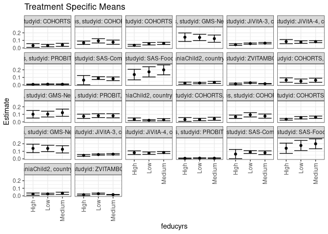

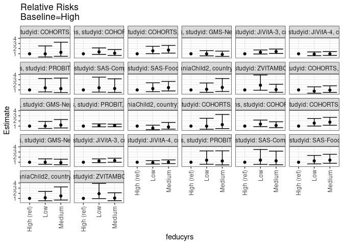

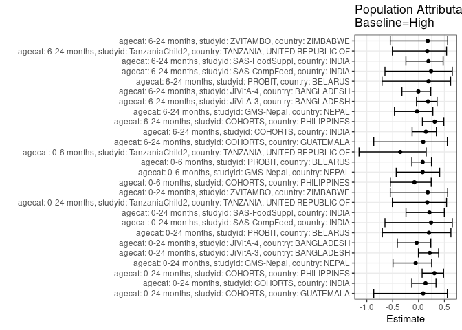

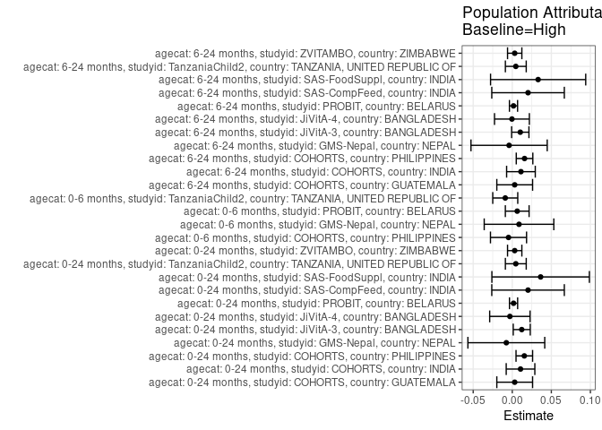

## Results Table

### Parameter: TSM

| agecat | studyid | country | intervention_level | baseline_level | estimate | ci_lower | ci_upper |
| --- | --- | --- | --- | --- | --- | --- | --- |
| 0-24 months | COHORTS | GUATEMALA | High | NA | 0.0319149 | 0.0067764 | 0.0570534 |
| 0-24 months | COHORTS | GUATEMALA | Low | NA | 0.0314607 | 0.0152340 | 0.0476873 |
| 0-24 months | COHORTS | GUATEMALA | Medium | NA | 0.0409836 | 0.0206627 | 0.0613045 |
| 0-24 months | COHORTS | INDIA | High | NA | 0.0683382 | 0.0459062 | 0.0907702 |
| 0-24 months | COHORTS | INDIA | Low | NA | 0.0939371 | 0.0654021 | 0.1224720 |
| 0-24 months | COHORTS | INDIA | Medium | NA | 0.0761968 | 0.0482305 | 0.1041631 |
| 0-24 months | COHORTS | PHILIPPINES | High | NA | 0.0349766 | 0.0232177 | 0.0467356 |
| 0-24 months | COHORTS | PHILIPPINES | Low | NA | 0.0552620 | 0.0391041 | 0.0714199 |
| 0-24 months | COHORTS | PHILIPPINES | Medium | NA | 0.0604175 | 0.0450885 | 0.0757464 |
| 0-24 months | GMS-Nepal | NEPAL | High | NA | 0.1418352 | 0.0851234 | 0.1985471 |
| 0-24 months | GMS-Nepal | NEPAL | Low | NA | 0.1387342 | 0.0969462 | 0.1805223 |
| 0-24 months | GMS-Nepal | NEPAL | Medium | NA | 0.1231369 | 0.0750979 | 0.1711759 |
| 0-24 months | JiVitA-3 | BANGLADESH | High | NA | 0.0440971 | 0.0327019 | 0.0554923 |
| 0-24 months | JiVitA-3 | BANGLADESH | Low | NA | 0.0571399 | 0.0490360 | 0.0652438 |
| 0-24 months | JiVitA-3 | BANGLADESH | Medium | NA | 0.0631772 | 0.0540553 | 0.0722990 |
| 0-24 months | JiVitA-4 | BANGLADESH | High | NA | 0.0841144 | 0.0564338 | 0.1117949 |
| 0-24 months | JiVitA-4 | BANGLADESH | Low | NA | 0.0781317 | 0.0612933 | 0.0949702 |
| 0-24 months | JiVitA-4 | BANGLADESH | Medium | NA | 0.0832351 | 0.0702713 | 0.0961990 |
| 0-24 months | PROBIT | BELARUS | High | NA | 0.0065384 | 0.0017065 | 0.0113703 |
| 0-24 months | PROBIT | BELARUS | Low | NA | 0.0092013 | 0.0048419 | 0.0135607 |
| 0-24 months | PROBIT | BELARUS | Medium | NA | 0.0082788 | 0.0032103 | 0.0133472 |
| 0-24 months | SAS-CompFeed | INDIA | High | NA | 0.0634408 | 0.0026712 | 0.1242103 |
| 0-24 months | SAS-CompFeed | INDIA | Low | NA | 0.0900586 | 0.0713513 | 0.1087659 |
| 0-24 months | SAS-CompFeed | INDIA | Medium | NA | 0.0810126 | 0.0564133 | 0.1056119 |
| 0-24 months | SAS-FoodSuppl | INDIA | High | NA | 0.1370333 | 0.0675231 | 0.2065435 |
| 0-24 months | SAS-FoodSuppl | INDIA | Low | NA | 0.1728836 | 0.1053018 | 0.2404655 |
| 0-24 months | SAS-FoodSuppl | INDIA | Medium | NA | 0.1990924 | 0.1336540 | 0.2645308 |
| 0-24 months | TanzaniaChild2 | TANZANIA, UNITED REPUBLIC OF | High | NA | 0.0223881 | 0.0079228 | 0.0368534 |
| 0-24 months | TanzaniaChild2 | TANZANIA, UNITED REPUBLIC OF | Low | NA | 0.0251736 | 0.0161255 | 0.0342217 |
| 0-24 months | TanzaniaChild2 | TANZANIA, UNITED REPUBLIC OF | Medium | NA | 0.0332779 | 0.0189349 | 0.0476209 |
| 0-24 months | ZVITAMBO | ZIMBABWE | High | NA | 0.0145161 | 0.0051010 | 0.0239312 |
| 0-24 months | ZVITAMBO | ZIMBABWE | Low | NA | 0.0278983 | 0.0198612 | 0.0359354 |
| 0-24 months | ZVITAMBO | ZIMBABWE | Medium | NA | 0.0155426 | 0.0126474 | 0.0184378 |
| 0-6 months | COHORTS | PHILIPPINES | High | NA | 0.0645100 | 0.0354238 | 0.0935962 |
| 0-6 months | COHORTS | PHILIPPINES | Low | NA | 0.0495890 | 0.0206927 | 0.0784852 |
| 0-6 months | COHORTS | PHILIPPINES | Medium | NA | 0.0618239 | 0.0346325 | 0.0890153 |
| 0-6 months | GMS-Nepal | NEPAL | High | NA | 0.1009094 | 0.0505008 | 0.1513180 |
| 0-6 months | GMS-Nepal | NEPAL | Low | NA | 0.1030248 | 0.0649753 | 0.1410743 |
| 0-6 months | GMS-Nepal | NEPAL | Medium | NA | 0.1217941 | 0.0739649 | 0.1696232 |
| 0-6 months | PROBIT | BELARUS | High | NA | 0.0740013 | 0.0455941 | 0.1024085 |
| 0-6 months | PROBIT | BELARUS | Low | NA | 0.0818579 | 0.0561640 | 0.1075518 |
| 0-6 months | PROBIT | BELARUS | Medium | NA | 0.0808838 | 0.0539068 | 0.1078607 |
| 0-6 months | TanzaniaChild2 | TANZANIA, UNITED REPUBLIC OF | High | NA | 0.0343288 | 0.0161303 | 0.0525273 |
| 0-6 months | TanzaniaChild2 | TANZANIA, UNITED REPUBLIC OF | Low | NA | 0.0206210 | 0.0122280 | 0.0290140 |
| 0-6 months | TanzaniaChild2 | TANZANIA, UNITED REPUBLIC OF | Medium | NA | 0.0285834 | 0.0146142 | 0.0425526 |
| 6-24 months | COHORTS | GUATEMALA | High | NA | 0.0319149 | 0.0067764 | 0.0570534 |
| 6-24 months | COHORTS | GUATEMALA | Low | NA | 0.0314607 | 0.0152340 | 0.0476873 |
| 6-24 months | COHORTS | GUATEMALA | Medium | NA | 0.0409836 | 0.0206627 | 0.0613045 |
| 6-24 months | COHORTS | INDIA | High | NA | 0.0677983 | 0.0453563 | 0.0902403 |
| 6-24 months | COHORTS | INDIA | Low | NA | 0.0939610 | 0.0654802 | 0.1224417 |
| 6-24 months | COHORTS | INDIA | Medium | NA | 0.0764018 | 0.0484682 | 0.1043354 |
| 6-24 months | COHORTS | PHILIPPINES | High | NA | 0.0346886 | 0.0229354 | 0.0464418 |
| 6-24 months | COHORTS | PHILIPPINES | Low | NA | 0.0548236 | 0.0387889 | 0.0708583 |
| 6-24 months | COHORTS | PHILIPPINES | Medium | NA | 0.0616163 | 0.0462584 | 0.0769742 |
| 6-24 months | GMS-Nepal | NEPAL | High | NA | 0.1382856 | 0.0820331 | 0.1945381 |
| 6-24 months | GMS-Nepal | NEPAL | Low | NA | 0.1377881 | 0.0957799 | 0.1797963 |
| 6-24 months | GMS-Nepal | NEPAL | Medium | NA | 0.1261553 | 0.0783726 | 0.1739380 |
| 6-24 months | JiVitA-3 | BANGLADESH | High | NA | 0.0459661 | 0.0342971 | 0.0576351 |
| 6-24 months | JiVitA-3 | BANGLADESH | Low | NA | 0.0568124 | 0.0486113 | 0.0650135 |
| 6-24 months | JiVitA-3 | BANGLADESH | Medium | NA | 0.0614228 | 0.0526233 | 0.0702223 |
| 6-24 months | JiVitA-4 | BANGLADESH | High | NA | 0.0814761 | 0.0572927 | 0.1056595 |
| 6-24 months | JiVitA-4 | BANGLADESH | Low | NA | 0.0756342 | 0.0596664 | 0.0916020 |
| 6-24 months | JiVitA-4 | BANGLADESH | Medium | NA | 0.0838713 | 0.0706042 | 0.0971383 |
| 6-24 months | PROBIT | BELARUS | High | NA | 0.0066002 | 0.0017373 | 0.0114631 |
| 6-24 months | PROBIT | BELARUS | Low | NA | 0.0092416 | 0.0048774 | 0.0136059 |
| 6-24 months | PROBIT | BELARUS | Medium | NA | 0.0082280 | 0.0032566 | 0.0131995 |
| 6-24 months | SAS-CompFeed | INDIA | High | NA | 0.0634408 | 0.0026712 | 0.1242103 |
| 6-24 months | SAS-CompFeed | INDIA | Low | NA | 0.0900586 | 0.0713513 | 0.1087659 |
| 6-24 months | SAS-CompFeed | INDIA | Medium | NA | 0.0810126 | 0.0564133 | 0.1056119 |
| 6-24 months | SAS-FoodSuppl | INDIA | High | NA | 0.1402283 | 0.0725019 | 0.2079547 |
| 6-24 months | SAS-FoodSuppl | INDIA | Low | NA | 0.1767041 | 0.1093492 | 0.2440590 |
| 6-24 months | SAS-FoodSuppl | INDIA | Medium | NA | 0.1989155 | 0.1333256 | 0.2645054 |
| 6-24 months | TanzaniaChild2 | TANZANIA, UNITED REPUBLIC OF | High | NA | 0.0223881 | 0.0079228 | 0.0368534 |
| 6-24 months | TanzaniaChild2 | TANZANIA, UNITED REPUBLIC OF | Low | NA | 0.0251736 | 0.0161255 | 0.0342217 |
| 6-24 months | TanzaniaChild2 | TANZANIA, UNITED REPUBLIC OF | Medium | NA | 0.0332779 | 0.0189349 | 0.0476209 |
| 6-24 months | ZVITAMBO | ZIMBABWE | High | NA | 0.0145161 | 0.0051010 | 0.0239312 |
| 6-24 months | ZVITAMBO | ZIMBABWE | Low | NA | 0.0278983 | 0.0198612 | 0.0359354 |
| 6-24 months | ZVITAMBO | ZIMBABWE | Medium | NA | 0.0155426 | 0.0126474 | 0.0184378 |

### Parameter: E(Y)

| agecat | studyid | country | intervention_level | baseline_level | estimate | ci_lower | ci_upper |
| --- | --- | --- | --- | --- | --- | --- | --- |
| 0-24 months | COHORTS | GUATEMALA | NA | NA | 0.0350350 | 0.0236276 | 0.0464425 |
| 0-24 months | COHORTS | INDIA | NA | NA | 0.0789050 | 0.0639058 | 0.0939041 |
| 0-24 months | COHORTS | PHILIPPINES | NA | NA | 0.0503949 | 0.0420785 | 0.0587113 |
| 0-24 months | GMS-Nepal | NEPAL | NA | NA | 0.1342282 | 0.1068369 | 0.1616195 |
| 0-24 months | JiVitA-3 | BANGLADESH | NA | NA | 0.0562249 | 0.0520204 | 0.0604294 |
| 0-24 months | JiVitA-4 | BANGLADESH | NA | NA | 0.0810600 | 0.0722782 | 0.0898418 |
| 0-24 months | PROBIT | BELARUS | NA | NA | 0.0081814 | 0.0045192 | 0.0118436 |
| 0-24 months | SAS-CompFeed | INDIA | NA | NA | 0.0836390 | 0.0602327 | 0.1070453 |
| 0-24 months | SAS-FoodSuppl | INDIA | NA | NA | 0.1733333 | 0.1349698 | 0.2116969 |
| 0-24 months | TanzaniaChild2 | TANZANIA, UNITED REPUBLIC OF | NA | NA | 0.0269142 | 0.0200799 | 0.0337484 |
| 0-24 months | ZVITAMBO | ZIMBABWE | NA | NA | 0.0176292 | 0.0149467 | 0.0203118 |
| 0-6 months | COHORTS | PHILIPPINES | NA | NA | 0.0597015 | 0.0433139 | 0.0760891 |
| 0-6 months | GMS-Nepal | NEPAL | NA | NA | 0.1095406 | 0.0837882 | 0.1352931 |
| 0-6 months | PROBIT | BELARUS | NA | NA | 0.0803428 | 0.0548486 | 0.1058370 |
| 0-6 months | TanzaniaChild2 | TANZANIA, UNITED REPUBLIC OF | NA | NA | 0.0253535 | 0.0185487 | 0.0321583 |
| 6-24 months | COHORTS | GUATEMALA | NA | NA | 0.0350350 | 0.0236276 | 0.0464425 |
| 6-24 months | COHORTS | INDIA | NA | NA | 0.0789050 | 0.0639058 | 0.0939041 |
| 6-24 months | COHORTS | PHILIPPINES | NA | NA | 0.0503949 | 0.0420785 | 0.0587113 |
| 6-24 months | GMS-Nepal | NEPAL | NA | NA | 0.1342282 | 0.1068369 | 0.1616195 |
| 6-24 months | JiVitA-3 | BANGLADESH | NA | NA | 0.0562249 | 0.0520204 | 0.0604294 |
| 6-24 months | JiVitA-4 | BANGLADESH | NA | NA | 0.0810600 | 0.0722782 | 0.0898418 |
| 6-24 months | PROBIT | BELARUS | NA | NA | 0.0081814 | 0.0045192 | 0.0118436 |
| 6-24 months | SAS-CompFeed | INDIA | NA | NA | 0.0836390 | 0.0602327 | 0.1070453 |
| 6-24 months | SAS-FoodSuppl | INDIA | NA | NA | 0.1733333 | 0.1349698 | 0.2116969 |
| 6-24 months | TanzaniaChild2 | TANZANIA, UNITED REPUBLIC OF | NA | NA | 0.0269142 | 0.0200799 | 0.0337484 |
| 6-24 months | ZVITAMBO | ZIMBABWE | NA | NA | 0.0176292 | 0.0149467 | 0.0203118 |

### Parameter: RR

| agecat | studyid | country | intervention_level | baseline_level | estimate | ci_lower | ci_upper |
| --- | --- | --- | --- | --- | --- | --- | --- |
| 0-24 months | COHORTS | GUATEMALA | High | High | 1.0000000 | 1.0000000 | 1.000000 |
| 0-24 months | COHORTS | GUATEMALA | Low | High | 0.9857678 | 0.3844846 | 2.527379 |
| 0-24 months | COHORTS | GUATEMALA | Medium | High | 1.2841530 | 0.5062921 | 3.257110 |
| 0-24 months | COHORTS | INDIA | High | High | 1.0000000 | 1.0000000 | 1.000000 |
| 0-24 months | COHORTS | INDIA | Low | High | 1.3745899 | 0.8789356 | 2.149756 |
| 0-24 months | COHORTS | INDIA | Medium | High | 1.1149943 | 0.6813285 | 1.824689 |
| 0-24 months | COHORTS | PHILIPPINES | High | High | 1.0000000 | 1.0000000 | 1.000000 |
| 0-24 months | COHORTS | PHILIPPINES | Low | High | 1.5799682 | 1.0118585 | 2.467044 |
| 0-24 months | COHORTS | PHILIPPINES | Medium | High | 1.7273668 | 1.1333105 | 2.632814 |
| 0-24 months | GMS-Nepal | NEPAL | High | High | 1.0000000 | 1.0000000 | 1.000000 |
| 0-24 months | GMS-Nepal | NEPAL | Low | High | 0.9781366 | 0.5939000 | 1.610963 |
| 0-24 months | GMS-Nepal | NEPAL | Medium | High | 0.8681684 | 0.4967241 | 1.517374 |
| 0-24 months | JiVitA-3 | BANGLADESH | High | High | 1.0000000 | 1.0000000 | 1.000000 |
| 0-24 months | JiVitA-3 | BANGLADESH | Low | High | 1.2957740 | 0.9646387 | 1.740579 |
| 0-24 months | JiVitA-3 | BANGLADESH | Medium | High | 1.4326826 | 1.0694728 | 1.919244 |
| 0-24 months | JiVitA-4 | BANGLADESH | High | High | 1.0000000 | 1.0000000 | 1.000000 |
| 0-24 months | JiVitA-4 | BANGLADESH | Low | High | 0.9288750 | 0.6333955 | 1.362196 |
| 0-24 months | JiVitA-4 | BANGLADESH | Medium | High | 0.9895473 | 0.6853306 | 1.428805 |
| 0-24 months | PROBIT | BELARUS | High | High | 1.0000000 | 1.0000000 | 1.000000 |
| 0-24 months | PROBIT | BELARUS | Low | High | 1.4072700 | 0.6130279 | 3.230536 |
| 0-24 months | PROBIT | BELARUS | Medium | High | 1.2661744 | 0.4857832 | 3.300232 |
| 0-24 months | SAS-CompFeed | INDIA | High | High | 1.0000000 | 1.0000000 | 1.000000 |
| 0-24 months | SAS-CompFeed | INDIA | Low | High | 1.4195700 | 0.5777883 | 3.487746 |
| 0-24 months | SAS-CompFeed | INDIA | Medium | High | 1.2769796 | 0.5149392 | 3.166737 |
| 0-24 months | SAS-FoodSuppl | INDIA | High | High | 1.0000000 | 1.0000000 | 1.000000 |
| 0-24 months | SAS-FoodSuppl | INDIA | Low | High | 1.2616180 | 0.6661910 | 2.389225 |
| 0-24 months | SAS-FoodSuppl | INDIA | Medium | High | 1.4528765 | 0.7936350 | 2.659724 |
| 0-24 months | TanzaniaChild2 | TANZANIA, UNITED REPUBLIC OF | High | High | 1.0000000 | 1.0000000 | 1.000000 |
| 0-24 months | TanzaniaChild2 | TANZANIA, UNITED REPUBLIC OF | Low | High | 1.1244213 | 0.5368195 | 2.355211 |
| 0-24 months | TanzaniaChild2 | TANZANIA, UNITED REPUBLIC OF | Medium | High | 1.4864115 | 0.6836450 | 3.231823 |
| 0-24 months | ZVITAMBO | ZIMBABWE | High | High | 1.0000000 | 1.0000000 | 1.000000 |
| 0-24 months | ZVITAMBO | ZIMBABWE | Low | High | 1.9218847 | 0.9451687 | 3.907917 |
| 0-24 months | ZVITAMBO | ZIMBABWE | Medium | High | 1.0707100 | 0.5452590 | 2.102524 |
| 0-6 months | COHORTS | PHILIPPINES | High | High | 1.0000000 | 1.0000000 | 1.000000 |
| 0-6 months | COHORTS | PHILIPPINES | Low | High | 0.7687022 | 0.3678691 | 1.606286 |
| 0-6 months | COHORTS | PHILIPPINES | Medium | High | 0.9583623 | 0.5103789 | 1.799562 |
| 0-6 months | GMS-Nepal | NEPAL | High | High | 1.0000000 | 1.0000000 | 1.000000 |
| 0-6 months | GMS-Nepal | NEPAL | Low | High | 1.0209636 | 0.5482510 | 1.901258 |
| 0-6 months | GMS-Nepal | NEPAL | Medium | High | 1.2069649 | 0.6389943 | 2.279777 |
| 0-6 months | PROBIT | BELARUS | High | High | 1.0000000 | 1.0000000 | 1.000000 |
| 0-6 months | PROBIT | BELARUS | Low | High | 1.1061687 | 0.8540785 | 1.432666 |
| 0-6 months | PROBIT | BELARUS | Medium | High | 1.0930048 | 0.8695358 | 1.373905 |
| 0-6 months | TanzaniaChild2 | TANZANIA, UNITED REPUBLIC OF | High | High | 1.0000000 | 1.0000000 | 1.000000 |
| 0-6 months | TanzaniaChild2 | TANZANIA, UNITED REPUBLIC OF | Low | High | 0.6006900 | 0.3078136 | 1.172230 |
| 0-6 months | TanzaniaChild2 | TANZANIA, UNITED REPUBLIC OF | Medium | High | 0.8326349 | 0.4047491 | 1.712866 |
| 6-24 months | COHORTS | GUATEMALA | High | High | 1.0000000 | 1.0000000 | 1.000000 |
| 6-24 months | COHORTS | GUATEMALA | Low | High | 0.9857678 | 0.3844846 | 2.527379 |
| 6-24 months | COHORTS | GUATEMALA | Medium | High | 1.2841530 | 0.5062921 | 3.257110 |
| 6-24 months | COHORTS | INDIA | High | High | 1.0000000 | 1.0000000 | 1.000000 |
| 6-24 months | COHORTS | INDIA | Low | High | 1.3858895 | 0.8845986 | 2.171256 |
| 6-24 months | COHORTS | INDIA | Medium | High | 1.1268989 | 0.6882870 | 1.845017 |
| 6-24 months | COHORTS | PHILIPPINES | High | High | 1.0000000 | 1.0000000 | 1.000000 |
| 6-24 months | COHORTS | PHILIPPINES | Low | High | 1.5804509 | 1.0101108 | 2.472823 |
| 6-24 months | COHORTS | PHILIPPINES | Medium | High | 1.7762705 | 1.1664697 | 2.704859 |
| 6-24 months | GMS-Nepal | NEPAL | High | High | 1.0000000 | 1.0000000 | 1.000000 |
| 6-24 months | GMS-Nepal | NEPAL | Low | High | 0.9964025 | 0.5997415 | 1.655410 |
| 6-24 months | GMS-Nepal | NEPAL | Medium | High | 0.9122810 | 0.5229215 | 1.591552 |
| 6-24 months | JiVitA-3 | BANGLADESH | High | High | 1.0000000 | 1.0000000 | 1.000000 |
| 6-24 months | JiVitA-3 | BANGLADESH | Low | High | 1.2359641 | 0.9251446 | 1.651209 |
| 6-24 months | JiVitA-3 | BANGLADESH | Medium | High | 1.3362634 | 1.0029715 | 1.780310 |
| 6-24 months | JiVitA-4 | BANGLADESH | High | High | 1.0000000 | 1.0000000 | 1.000000 |
| 6-24 months | JiVitA-4 | BANGLADESH | Low | High | 0.9282987 | 0.6523289 | 1.321018 |
| 6-24 months | JiVitA-4 | BANGLADESH | Medium | High | 1.0293973 | 0.7331201 | 1.445410 |
| 6-24 months | PROBIT | BELARUS | High | High | 1.0000000 | 1.0000000 | 1.000000 |
| 6-24 months | PROBIT | BELARUS | Low | High | 1.4001984 | 0.6108397 | 3.209607 |
| 6-24 months | PROBIT | BELARUS | Medium | High | 1.2466328 | 0.4821938 | 3.222964 |
| 6-24 months | SAS-CompFeed | INDIA | High | High | 1.0000000 | 1.0000000 | 1.000000 |
| 6-24 months | SAS-CompFeed | INDIA | Low | High | 1.4195700 | 0.5777883 | 3.487746 |
| 6-24 months | SAS-CompFeed | INDIA | Medium | High | 1.2769796 | 0.5149392 | 3.166737 |
| 6-24 months | SAS-FoodSuppl | INDIA | High | High | 1.0000000 | 1.0000000 | 1.000000 |
| 6-24 months | SAS-FoodSuppl | INDIA | Low | High | 1.2601171 | 0.6837239 | 2.322422 |
| 6-24 months | SAS-FoodSuppl | INDIA | Medium | High | 1.4185119 | 0.7903450 | 2.545946 |
| 6-24 months | TanzaniaChild2 | TANZANIA, UNITED REPUBLIC OF | High | High | 1.0000000 | 1.0000000 | 1.000000 |
| 6-24 months | TanzaniaChild2 | TANZANIA, UNITED REPUBLIC OF | Low | High | 1.1244213 | 0.5368195 | 2.355211 |
| 6-24 months | TanzaniaChild2 | TANZANIA, UNITED REPUBLIC OF | Medium | High | 1.4864115 | 0.6836450 | 3.231823 |
| 6-24 months | ZVITAMBO | ZIMBABWE | High | High | 1.0000000 | 1.0000000 | 1.000000 |
| 6-24 months | ZVITAMBO | ZIMBABWE | Low | High | 1.9218847 | 0.9451687 | 3.907917 |
| 6-24 months | ZVITAMBO | ZIMBABWE | Medium | High | 1.0707100 | 0.5452590 | 2.102524 |

### Parameter: PAR

| agecat | studyid | country | intervention_level | baseline_level | estimate | ci_lower | ci_upper |
| --- | --- | --- | --- | --- | --- | --- | --- |
| 0-24 months | COHORTS | GUATEMALA | High | NA | 0.0031201 | -0.0197759 | 0.0260162 |
| 0-24 months | COHORTS | INDIA | High | NA | 0.0105667 | -0.0077533 | 0.0288868 |
| 0-24 months | COHORTS | PHILIPPINES | High | NA | 0.0154183 | 0.0048096 | 0.0260269 |
| 0-24 months | GMS-Nepal | NEPAL | High | NA | -0.0076070 | -0.0567743 | 0.0415602 |
| 0-24 months | JiVitA-3 | BANGLADESH | High | NA | 0.0121278 | 0.0012469 | 0.0230087 |
| 0-24 months | JiVitA-4 | BANGLADESH | High | NA | -0.0030544 | -0.0288953 | 0.0227866 |
| 0-24 months | PROBIT | BELARUS | High | NA | 0.0016430 | -0.0035804 | 0.0068663 |
| 0-24 months | SAS-CompFeed | INDIA | High | NA | 0.0201982 | -0.0262224 | 0.0666189 |
| 0-24 months | SAS-FoodSuppl | INDIA | High | NA | 0.0363001 | -0.0260917 | 0.0986919 |
| 0-24 months | TanzaniaChild2 | TANZANIA, UNITED REPUBLIC OF | High | NA | 0.0045261 | -0.0088113 | 0.0178635 |
| 0-24 months | ZVITAMBO | ZIMBABWE | High | NA | 0.0031131 | -0.0060494 | 0.0122757 |
| 0-6 months | COHORTS | PHILIPPINES | High | NA | -0.0048085 | -0.0278967 | 0.0182797 |
| 0-6 months | GMS-Nepal | NEPAL | High | NA | 0.0086313 | -0.0359106 | 0.0531731 |
| 0-6 months | PROBIT | BELARUS | High | NA | 0.0063415 | -0.0088558 | 0.0215388 |
| 0-6 months | TanzaniaChild2 | TANZANIA, UNITED REPUBLIC OF | High | NA | -0.0089753 | -0.0249727 | 0.0070220 |
| 6-24 months | COHORTS | GUATEMALA | High | NA | 0.0031201 | -0.0197759 | 0.0260162 |
| 6-24 months | COHORTS | INDIA | High | NA | 0.0111067 | -0.0072322 | 0.0294456 |
| 6-24 months | COHORTS | PHILIPPINES | High | NA | 0.0157063 | 0.0051020 | 0.0263106 |
| 6-24 months | GMS-Nepal | NEPAL | High | NA | -0.0040574 | -0.0528376 | 0.0447229 |
| 6-24 months | JiVitA-3 | BANGLADESH | High | NA | 0.0102588 | -0.0008190 | 0.0213366 |
| 6-24 months | JiVitA-4 | BANGLADESH | High | NA | -0.0004161 | -0.0227169 | 0.0218847 |
| 6-24 months | PROBIT | BELARUS | High | NA | 0.0015812 | -0.0036320 | 0.0067944 |
| 6-24 months | SAS-CompFeed | INDIA | High | NA | 0.0201982 | -0.0262224 | 0.0666189 |
| 6-24 months | SAS-FoodSuppl | INDIA | High | NA | 0.0331050 | -0.0277834 | 0.0939935 |
| 6-24 months | TanzaniaChild2 | TANZANIA, UNITED REPUBLIC OF | High | NA | 0.0045261 | -0.0088113 | 0.0178635 |
| 6-24 months | ZVITAMBO | ZIMBABWE | High | NA | 0.0031131 | -0.0060494 | 0.0122757 |

### Parameter: PAF

| agecat | studyid | country | intervention_level | baseline_level | estimate | ci_lower | ci_upper |
| --- | --- | --- | --- | --- | --- | --- | --- |
| 0-24 months | COHORTS | GUATEMALA | High | NA | 0.0890578 | -0.8653949 | 0.5551528 |
| 0-24 months | COHORTS | INDIA | High | NA | 0.1339174 | -0.1307053 | 0.3366095 |
| 0-24 months | COHORTS | PHILIPPINES | High | NA | 0.3059488 | 0.0687512 | 0.4827300 |
| 0-24 months | GMS-Nepal | NEPAL | High | NA | -0.0566725 | -0.4944386 | 0.2528587 |
| 0-24 months | JiVitA-3 | BANGLADESH | High | NA | 0.2157014 | -0.0032462 | 0.3868661 |
| 0-24 months | JiVitA-4 | BANGLADESH | High | NA | -0.0376801 | -0.4106349 | 0.2366699 |
| 0-24 months | PROBIT | BELARUS | High | NA | 0.2008178 | -0.6996091 | 0.6242124 |
| 0-24 months | SAS-CompFeed | INDIA | High | NA | 0.2414930 | -0.6486777 | 0.6510338 |
| 0-24 months | SAS-FoodSuppl | INDIA | High | NA | 0.2094235 | -0.2430300 | 0.4971874 |
| 0-24 months | TanzaniaChild2 | TANZANIA, UNITED REPUBLIC OF | High | NA | 0.1681678 | -0.5060612 | 0.5405599 |
| 0-24 months | ZVITAMBO | ZIMBABWE | High | NA | 0.1765882 | -0.5466324 | 0.5616237 |
| 0-6 months | COHORTS | PHILIPPINES | High | NA | -0.0805421 | -0.5445750 | 0.2440824 |
| 0-6 months | GMS-Nepal | NEPAL | High | NA | 0.0787950 | -0.4316955 | 0.4072632 |
| 0-6 months | PROBIT | BELARUS | High | NA | 0.0789305 | -0.1301492 | 0.2493301 |
| 0-6 months | TanzaniaChild2 | TANZANIA, UNITED REPUBLIC OF | High | NA | -0.3540075 | -1.1489980 | 0.1468878 |
| 6-24 months | COHORTS | GUATEMALA | High | NA | 0.0890578 | -0.8653949 | 0.5551528 |
| 6-24 months | COHORTS | INDIA | High | NA | 0.1407603 | -0.1244686 | 0.3434296 |
| 6-24 months | COHORTS | PHILIPPINES | High | NA | 0.3116643 | 0.0743051 | 0.4881618 |
| 6-24 months | GMS-Nepal | NEPAL | High | NA | -0.0302275 | -0.4659495 | 0.2759855 |
| 6-24 months | JiVitA-3 | BANGLADESH | High | NA | 0.1824607 | -0.0401479 | 0.3574274 |
| 6-24 months | JiVitA-4 | BANGLADESH | High | NA | -0.0051333 | -0.3215630 | 0.2355318 |
| 6-24 months | PROBIT | BELARUS | High | NA | 0.1932627 | -0.7052534 | 0.6183411 |
| 6-24 months | SAS-CompFeed | INDIA | High | NA | 0.2414930 | -0.6486777 | 0.6510338 |
| 6-24 months | SAS-FoodSuppl | INDIA | High | NA | 0.1909906 | -0.2445448 | 0.4741079 |
| 6-24 months | TanzaniaChild2 | TANZANIA, UNITED REPUBLIC OF | High | NA | 0.1681678 | -0.5060612 | 0.5405599 |
| 6-24 months | ZVITAMBO | ZIMBABWE | High | NA | 0.1765882 | -0.5466324 | 0.5616237 |